# Meaningfulness5_updated

Prolific

Cognitive Neuroscience Lab @ Yonsei Univ

2024-12-21

```r
set.seed(1234567) # for reproducibility
options("scipen" = 100) # https://rfriend.tistory.com/224

pacman::p_load(tidyverse, psych, knitr, rstatix, gghalves, ggpubr, BayesFactor, emmeans)
options(dplyr.summarise.inform=FALSE) # suppress warning in regards to regrouping

options(knitr.kable.NA = '')
klippy::klippy()
```

# 1 Demographic

2024년 10월 11일에 Prolific에서 피험자 40명을 모집하였다. 2024년 10월 13일까지 피험자 20명을 추가로 모집하여 총 60명의 참가자를 모집하였다.

```r
demographic <- bind_rows(list(
  read.csv('M5data/data_exp_192790-v3_questionnaire-f86v.csv', header = T),
  read.csv('M5data/data_exp_192790-v4_questionnaire-f86v.csv', header = T)))
dim(demographic)
## [1] 423  64

dg <- demographic %>%
  filter(Key == "value") %>%
  select(Participant.Private.ID,
         Object.ID,
         Response) %>%
  rename(Subject = Participant.Private.ID,
         Query = Object.ID) %>%
  mutate(Query = factor(Query,
                        levels = c('object-7', 'object-8'),
                        labels = c('gender', 'age'))) %>%
  pivot_wider(id_cols = c(Subject),
              names_from = Query,
              values_from = Response) %>%
  mutate(Subject = factor(Subject),
         gender = factor(gender),
         age = as.numeric(age))

dg %>%
  group_by(gender) %>%
  summarise(n = n()) %>%
  kable(digits = 3, format = "simple", caption = 'demographic: Gender')
```

demographic: Gender

| gender | n |
| --- | --- |
| __other | 1 |
| Female | 29 |
| Male | 30 |

```r
dg %>%
  get_summary_stats(age, type = 'common') %>%
  kable(digits = 3, format = "simple", caption = 'demographic: Age')
```

demographic: Age

| variable | n | min | max | median | iqr | mean | sd | se | ci |
| --- | --- | --- | --- | --- | --- | --- | --- | --- | --- |
| age | 60 | 18 | 41 | 27 | 6 | 27.283 | 4.723 | 0.61 | 1.22 |

# 2 Post-test query

실험 종료 후, 피험자에게 과제에서 단서를 활용했는지 물었다.

```r
postquery <- bind_rows(list(
  read.csv('M5data/data_exp_192790-v3_questionnaire-7u53.csv', header = T),
  read.csv('M5data/data_exp_192790-v4_questionnaire-7u53.csv', header = T)))
dim(postquery)
## [1] 237  63

pq <- postquery %>%
  filter(Key == "quantised") %>%
  select(Participant.Private.ID,
         Response) %>%
  rename(Subject = Participant.Private.ID,
         Strategy = Response) %>%
  mutate(Subject = factor(Subject),
         Strategy = factor(Strategy))

# 앞뒤 설문 자료를 합친다.
qs <- full_join(dg, pq, by = 'Subject')
qs %>% print(n = Inf)
## # A tibble: 60 × 4
##    Subject  gender    age Strategy
##    <fct>    <fct>   <dbl> <fct>
##  1 11834830 Female     26 1
##  2 11834841 Female     34 1
##  3 11834842 Male       27 1
##  4 11834852 Female     22 1
##  5 11834855 Female     28 1
##  6 11834859 Male       29 1
##  7 11834862 Male       27 2
##  8 11834864 Male       30 2
##  9 11834870 Male       33 3
## 10 11834871 Male       41 2
## 11 11834877 Male       24 1
## 12 11834878 Male       27 1
## 13 11834881 Male       27 1
## 14 11834882 Male       34 1
## 15 11834884 Female     19 1
## 16 11834887 Female     22 1
## 17 11834892 Female     29 3
## 18 11834901 Female     21 <NA>
## 19 11834903 Male       33 1
## 20 11834912 Female     29 2
## 21 11834915 Female     24 1
## 22 11834922 Male       20 1
## 23 11834926 Female     24 1
## 24 11834929 Female     26 2
## 25 11834935 Female     25 1
## 26 11834940 Male       31 1
## 27 11834942 Male       33 1
## 28 11834946 Female     30 3
## 29 11834950 Male       18 1
## 30 11834954 Female     30 1
## 31 11834961 Male       19 1
## 32 11834978 Female     35 1
## 33 11834988 __other    26 1
## 34 11834999 Male       28 1
## 35 11835015 Female     34 <NA>
## 36 11835032 Male       26 2
## 37 11835044 Female     27 3
## 38 11835099 Male       21 1
## 39 11835428 Male       27 1
## 40 11838226 Female     33 1
## 41 11840184 Male       26 1
## 42 11840195 Female     27 1
## 43 11840205 Female     24 1
## 44 11840207 Male       21 1
## 45 11840214 Male       24 1
## 46 11840229 Male       27 3
## 47 11840246 Male       21 1
## 48 11840252 Male       29 1
## 49 11840262 Female     26 2
## 50 11840269 Female     21 1
## 51 11840273 Female     30 3
## 52 11840276 Female     27 1
## 53 11840278 Female     32 1
## 54 11840290 Female     32 <NA>
## 55 11840304 Female     32 1
## 56 11840324 Male       29 1
## 57 11840325 Female     35 1
## 58 11840347 Male       26 2
## 59 11840854 Male       25 3
## 60 11842890 Male       24 2

qs$Strategy[is.na(qs$Strategy)] <- as.factor(3)

qs %>%
  group_by(Strategy) %>%
  summarise(n = n()) %>%
  kable(digits = 3, format = "simple")
```

| Strategy | n |
| --- | --- |
| 1 | 41 |
| 2 | 9 |
| 3 | 10 |

단서를 활용하여 3개의 물체를 기억했는지(`1`) 아니면 단서를 무시하고 6개의 물체를 모두 기억했는지(`2`)에 대해 사후 설문을 실시하였다. 그 결과, 단서를 활용했다는 응답은 41 명으로 대부분의 참가들이 단서를 사용했음 알 수 있었다.  
기타 답변(`3`)으는 “두 물체씩만 기억했다”는 답변(4명)과 “물체가 아닌 색 패턴을 기억했다”(2명), “두 전략을 모두 사용했다”(1명) 그리고 미응답자(3명)가 있었다.

# 3 Main data

## 3.1 데이터 불러오기

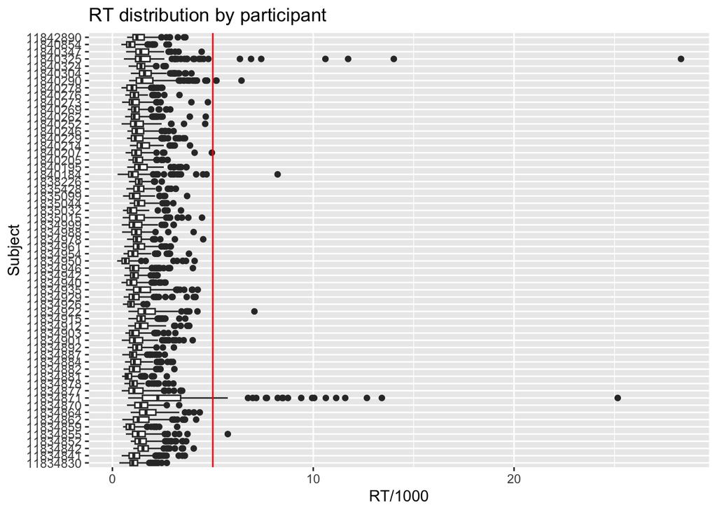

```r
g1 <- bind_rows(list(
  read.csv('M5data/data_exp_192790-v3_task-c84a.csv', header = T),  # v01NO1
  read.csv('M5data/data_exp_192790-v4_task-c84a.csv', header = T),
  read.csv('M5data/data_exp_192790-v3_task-pnh5.csv', header = T),  # v04AR2
  read.csv('M5data/data_exp_192790-v4_task-pnh5.csv', header = T)))
g2 <- bind_rows(list(
  read.csv('M5data/data_exp_192790-v3_task-vxbk.csv', header = T),  # v02NO2
  read.csv('M5data/data_exp_192790-v4_task-vxbk.csv', header = T),
  read.csv('M5data/data_exp_192790-v3_task-dg8d.csv', header = T),  # v03AR1
  read.csv('M5data/data_exp_192790-v4_task-dg8d.csv', header = T)))
g3 <- bind_rows(list(
  read.csv('M5data/data_exp_192790-v3_task-4zc6.csv', header = T),  # v03AR1
  read.csv('M5data/data_exp_192790-v4_task-4zc6.csv', header = T),
  read.csv('M5data/data_exp_192790-v3_task-8g9j.csv', header = T),  # v02NO2
  read.csv('M5data/data_exp_192790-v4_task-8g9j.csv', header = T)))
g4 <- bind_rows(list(
  read.csv('M5data/data_exp_192790-v3_task-dwtv.csv', header = T),  # v04AR2
  read.csv('M5data/data_exp_192790-v4_task-dwtv.csv', header = T),
  read.csv('M5data/data_exp_192790-v3_task-locf.csv', header = T),  # v01NO1
  read.csv('M5data/data_exp_192790-v4_task-locf.csv', header = T)))

dim(g1)
## [1] 28044   114
dim(g2)
## [1] 26284   114
dim(g3)
## [1] 26284   114
dim(g4)
## [1] 24532   114

mainTest <- bind_rows(list(g1, g2, g3, g4))
dim(mainTest)
## [1] 105144    114
# str(mainTest)

mt <- mainTest %>%
  filter(Screen == "test") %>%
  select(Participant.Private.ID,
         allocator.3ka9,
         Trial.Number,
         Spreadsheet..suffix,
         Spreadsheet..cue,
         Spreadsheet..tarLoc, # 목표 자극 위치
         Spreadsheet..tarDis,
         Response, # 실제 응답 위치
         Correct,
         Reaction.Time) %>%
  rename(Subject = Participant.Private.ID,
         Group = allocator.3ka9,
         Trials = Trial.Number,
         Stimulus = Spreadsheet..suffix,
         Cue = Spreadsheet..cue,
         Order = Spreadsheet..tarDis, # 첫 번째 vs. 두 번째 화면
         Key = Spreadsheet..tarLoc,
         RT = Reaction.Time) %>%
  mutate(Subject = factor(Subject),
         Stimulus = factor(Stimulus,
                           levels = c('.jpg', '_scram.jpg'),
                           labels = c('Intact', 'Scrambled')),
         Cue = factor(Cue,
                      levels = c(0, 1),
                      labels = c('NoCue', 'RetroCue')),
         Order = factor(Order,
                      levels = c(1, 2),
                      labels = c('First', 'Second'))) %>%
  group_by(Subject) %>%
  mutate(SN = cur_group_id(),
         SN = factor(SN)) %>%
  ungroup()

# table(mt$SN)
table(mt$Group)/192
##
## AR1NO2 AR2NO1 NO1AR2 NO2AR1
##     15     14     16     15
# table(mt$Subject, mt$Order)
# table(mt$Subject, mt$Correct)
# table(mt$Subject, mt$Stimulus)

# 참가자별 반응시간 분포
mt %>%
  ggplot(aes(x = Subject, y = RT/1000)) +
  geom_boxplot() +
  geom_hline(yintercept = 5, color = 'red') +
  coord_flip() +
  ggtitle('RT distribution by participant')
```

```r
# # 참가자별 반응시간; 5초 기준
mt %>%
  summarise(n = sum(RT > 5000))
## # A tibble: 1 × 1
##       n
##   <int>
## 1    38

# 5초이상 반응 오답처리하기
mt <- mt %>%
  mutate(Correct = ifelse(RT > 5000, 0, Correct))
```

11834871(25시행), 11840325(7시행) 참가자가 느린 반응을 많이 보임.

## 3.2 Outlier Detection

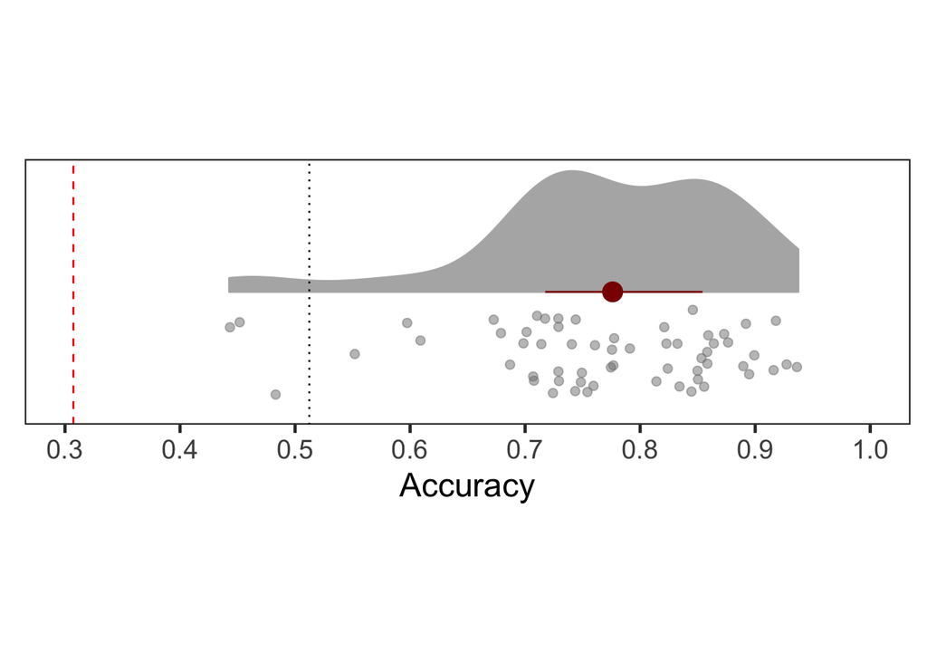

```r
# subject-specific performance
mt.gacc <- mt %>%
  group_by(Subject, SN) %>%
  summarise(M = mean(Correct)) %>%
  ungroup()

mt.gacc %>% print(n = Inf)
## # A tibble: 60 × 3
##    Subject  SN        M
##    <fct>    <fct> <dbl>
##  1 11834830 1     0.719
##  2 11834841 2     0.854
##  3 11834842 3     0.849
##  4 11834852 4     0.917
##  5 11834855 5     0.854
##  6 11834859 6     0.891
##  7 11834862 7     0.484
##  8 11834864 8     0.75
##  9 11834870 9     0.755
## 10 11834871 10    0.776
## 11 11834877 11    0.776
## 12 11834878 12    0.938
## 13 11834881 13    0.745
## 14 11834882 14    0.849
## 15 11834884 15    0.776
## 16 11834887 16    0.859
## 17 11834892 17    0.896
## 18 11834901 18    0.875
## 19 11834903 19    0.833
## 20 11834912 20    0.724
## 21 11834915 21    0.708
## 22 11834922 22    0.708
## 23 11834926 23    0.901
## 24 11834929 24    0.677
## 25 11834935 25    0.833
## 26 11834940 26    0.917
## 27 11834942 27    0.844
## 28 11834946 28    0.891
## 29 11834950 29    0.453
## 30 11834954 30    0.698
## 31 11834961 31    0.844
## 32 11834978 32    0.729
## 33 11834988 33    0.75
## 34 11834999 34    0.688
## 35 11835015 35    0.443
## 36 11835032 36    0.812
## 37 11835044 37    0.865
## 38 11835099 38    0.823
## 39 11835428 39    0.792
## 40 11838226 40    0.729
## 41 11840184 41    0.776
## 42 11840195 42    0.823
## 43 11840205 43    0.714
## 44 11840207 44    0.599
## 45 11840214 45    0.823
## 46 11840229 46    0.729
## 47 11840246 47    0.740
## 48 11840252 48    0.552
## 49 11840262 49    0.875
## 50 11840269 50    0.859
## 51 11840273 51    0.672
## 52 11840276 52    0.760
## 53 11840278 53    0.927
## 54 11840290 54    0.703
## 55 11840304 55    0.760
## 56 11840324 56    0.745
## 57 11840325 57    0.609
## 58 11840347 58    0.708
## 59 11840854 59    0.859
## 60 11842890 60    0.729

gacc.sum <- mt.gacc %>%
  summarise(MN = mean(M)
            , SD = sd(M)
            , MIN = min(M)
            , MAX = max(M)
            , Q1 = quantile(M, prob = .25)
            , MED = median(M)
            , Q3 = quantile(M, prob = .75)
            , IQR = IQR(M)
            , Outlier = Q1 - 1.5 * IQR
            , Extreme = Q1 - 3 * IQR)

mt.gacc %>%
  single_raincloud_plot(.$M, 0.3, 1, 0.1, "Accuracy") +
  geom_hline(yintercept=gacc.sum$Outlier, linetype="dotted") +
  geom_hline(yintercept=gacc.sum$Extreme, linetype='dashed', color='red', linewidth=0.5)
```

```r
mt.gacc %>% identify_outliers(M)
## # A tibble: 3 × 5
##   Subject  SN        M is.outlier is.extreme
##   <fct>    <fct> <dbl> <lgl>      <lgl>
## 1 11834862 7     0.484 TRUE       FALSE
## 2 11834950 29    0.453 TRUE       FALSE
## 3 11835015 35    0.443 TRUE       FALSE
mt %>% filter(SN==07) %>% slice(1L)
## # A tibble: 1 × 11
##   Subject  Group  Trials Stimulus Cue     Key Order Response Correct    RT SN
##   <fct>    <chr>   <int> <fct>    <fct> <int> <fct> <chr>      <dbl> <dbl> <fct>
## 1 11834862 NO2AR1      1 Intact   NoCue     1 First 3              0 1116. 7
mt %>% filter(SN==29) %>% slice(1L)
## # A tibble: 1 × 11
##   Subject  Group  Trials Stimulus Cue     Key Order Response Correct    RT SN
##   <fct>    <chr>   <int> <fct>    <fct> <int> <fct> <chr>      <dbl> <dbl> <fct>
## 1 11834950 AR1NO2      1 Intact   Retr…     3 First 3              1  516. 29
mt %>% filter(SN==35) %>% slice(1L)
## # A tibble: 1 × 11
##   Subject  Group  Trials Stimulus Cue     Key Order Response Correct    RT SN
##   <fct>    <chr>   <int> <fct>    <fct> <int> <fct> <chr>      <dbl> <dbl> <fct>
## 1 11835015 AR2NO1      1 Scrambl… Retr…     5 First 4              0  866. 35

mt <- rm_subject(mt, c(7, 29, 35))
## 3 removed & 57 left

table(mt$Group)/192 # 역균형 집단 크기 확인
##
## AR1NO2 AR2NO1 NO1AR2 NO2AR1
##     14     13     16     14
```

## 3.3 N = 57

### 3.3.1 Descriptive Stats

```r
mt.ind <- mt %>%
  group_by(SN, Stimulus, Cue, Order) %>%
  summarise(Accuracy = mean(Correct)) %>%
  ungroup()

mt.ind %>%
  group_by(Stimulus, Cue) %>%
  get_summary_stats(Accuracy, type = "common") %>%
  kable(digits = 3, format = "simple", caption = "Descriptive Stats without Order")
```

Descriptive Stats without Order

| Stimulus | Cue | variable | n | min | max | median | iqr | mean | sd | se | ci |
| --- | --- | --- | --- | --- | --- | --- | --- | --- | --- | --- | --- |
| Intact | NoCue | Accuracy | 114 | 0.419 | 1 | 0.826 | 0.198 | 0.800 | 0.136 | 0.013 | 0.025 |
| Intact | RetroCue | Accuracy | 114 | 0.476 | 1 | 0.857 | 0.164 | 0.838 | 0.123 | 0.011 | 0.023 |
| Scrambled | NoCue | Accuracy | 114 | 0.333 | 1 | 0.745 | 0.231 | 0.720 | 0.147 | 0.014 | 0.027 |
| Scrambled | RetroCue | Accuracy | 114 | 0.360 | 1 | 0.810 | 0.231 | 0.788 | 0.146 | 0.014 | 0.027 |

```r
mt.ind %>%
  group_by(SN, Stimulus, Cue) %>%
  summarise(Accuracy = mean(Accuracy)) %>%
  unite(col = 'Condition', Stimulus:Cue) %>%
  pivot_wider(id_cols = c(SN),
              names_from = Condition, values_from = Accuracy) %>%
  mutate(Intact = Intact_RetroCue - Intact_NoCue, # 화살표 단서 활용 효과
         Scrambled = Scrambled_RetroCue - Scrambled_NoCue) %>%
  select(SN, Intact, Scrambled) %>%
  pivot_longer(cols = c(Intact, Scrambled),
               names_to = 'Stimulus',
               values_to = 'CueBenefit') %>%
  group_by(Stimulus) %>%
  get_summary_stats(CueBenefit, type = "common") %>%
  kable(digits = 3, format = "simple", caption = "CueBenefit")
```

CueBenefit

| Stimulus | variable | n | min | max | median | iqr | mean | sd | se | ci |
| --- | --- | --- | --- | --- | --- | --- | --- | --- | --- | --- |
| Intact | CueBenefit | 57 | -0.147 | 0.248 | 0.037 | 0.083 | 0.038 | 0.087 | 0.012 | 0.023 |
| Scrambled | CueBenefit | 57 | -0.124 | 0.242 | 0.058 | 0.134 | 0.069 | 0.088 | 0.012 | 0.023 |

```r
mt.ind %>%
  group_by(Stimulus, Cue, Order) %>%
  get_summary_stats(Accuracy, type = "common") %>%
  kable(digits = 3, format = "simple", caption = "Descriptive Stats with Order")
```

Descriptive Stats with Order

| Stimulus | Cue | Order | variable | n | min | max | median | iqr | mean | sd | se | ci |
| --- | --- | --- | --- | --- | --- | --- | --- | --- | --- | --- | --- | --- |
| Intact | NoCue | First | Accuracy | 57 | 0.419 | 1.000 | 0.741 | 0.218 | 0.737 | 0.146 | 0.019 | 0.039 |
| Intact | NoCue | Second | Accuracy | 57 | 0.542 | 1.000 | 0.864 | 0.114 | 0.863 | 0.091 | 0.012 | 0.024 |
| Intact | RetroCue | First | Accuracy | 57 | 0.476 | 1.000 | 0.815 | 0.167 | 0.785 | 0.126 | 0.017 | 0.033 |
| Intact | RetroCue | Second | Accuracy | 57 | 0.630 | 1.000 | 0.905 | 0.120 | 0.890 | 0.094 | 0.012 | 0.025 |
| Scrambled | NoCue | First | Accuracy | 57 | 0.407 | 0.933 | 0.619 | 0.179 | 0.653 | 0.127 | 0.017 | 0.034 |
| Scrambled | NoCue | Second | Accuracy | 57 | 0.333 | 1.000 | 0.792 | 0.141 | 0.786 | 0.136 | 0.018 | 0.036 |
| Scrambled | RetroCue | First | Accuracy | 57 | 0.360 | 0.958 | 0.720 | 0.185 | 0.712 | 0.139 | 0.018 | 0.037 |
| Scrambled | RetroCue | Second | Accuracy | 57 | 0.476 | 1.000 | 0.889 | 0.116 | 0.865 | 0.109 | 0.014 | 0.029 |

### 3.3.2 Graph

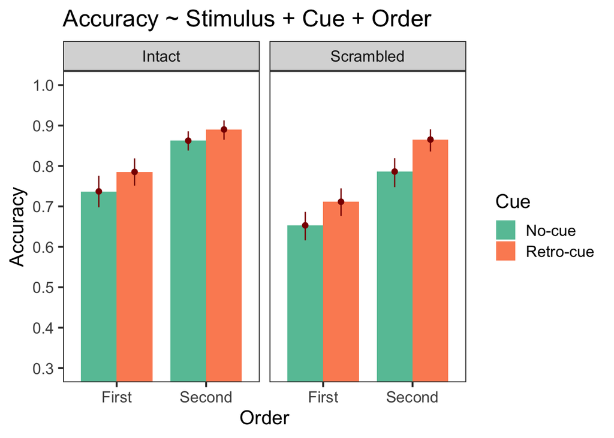

```r
mt.ind %>% ggplot(aes(x = Order, Stimulus, y = Accuracy, fill = Cue)) +
  stat_summary(fun = mean,
               geom = "bar",
               position = position_dodge(width = 0.8),
               aes(fill = Cue),
               width = 0.8) +
  stat_summary(fun.data = "mean_cl_boot",
               position = position_dodge(width = 0.8),
               color = "darkred",
               size = 0.3, show.legend = FALSE) +
  facet_wrap(~Stimulus) +
  coord_cartesian(ylim = c(0.3, 1), clip = "on") +
  scale_y_continuous(breaks=seq(0.3, 1, by = 0.1)) +
  scale_fill_brewer(labels = c("NoCue" = "No-cue", "RetroCue" = "Retro-cue"),
                    palette = "Set2") +
  labs(x = "Order", y = "Accuracy") +
  ggtitle('Accuracy ~ Stimulus + Cue + Order') +
  theme_bw(base_size = 16) +
  theme(panel.grid.major = element_blank(),
        panel.grid.minor = element_blank())
```

### 3.3.3 Anova

```r
anova_test(
  data = mt.ind, dv = Accuracy, wid = SN,
  within = c(Stimulus, Cue, Order),
  effect.size = "pes"
) %>% get_anova_table() %>%
  kable(digits = 3, format = "simple", caption = "ANOVA")
```

ANOVA

| Effect | DFn | DFd | F | p | p<.05 | pes |
| --- | --- | --- | --- | --- | --- | --- |
| Stimulus | 1 | 56 | 50.077 | 0.000 | * | 0.472 |
| Cue | 1 | 56 | 43.820 | 0.000 | * | 0.439 |
| Order | 1 | 56 | 157.095 | 0.000 | * | 0.737 |
| Stimulus:Cue | 1 | 56 | 3.428 | 0.069 |  | 0.058 |
| Stimulus:Order | 1 | 56 | 2.411 | 0.126 |  | 0.041 |
| Cue:Order | 1 | 56 | 0.000 | 0.997 |  | 0.000 |
| Stimulus:Cue:Order | 1 | 56 | 1.752 | 0.191 |  | 0.030 |

## 3.4 N = 40 (Compliant Subjects)

Post-query에서 지시를 따라 과제를 수행했다고 응답한 피험자들만 포함.

```r
mt2 <- full_join( mt %>% group_by(Subject) %>% nest(),
                  qs %>% select(Subject, Strategy),
                  by = join_by(Subject)) %>%
  unnest(data) %>%
  ungroup()
slice_sample(mt2, n = 10)
## # A tibble: 10 × 12
##    Subject  Group Trials Stimulus Cue     Key Order Response Correct    RT SN
##    <fct>    <chr>  <int> <fct>    <fct> <int> <fct> <chr>      <dbl> <dbl> <fct>
##  1 11835044 NO2A…     82 Intact   NoCue     3 First 1              0 1734. 37
##  2 11835044 NO2A…     33 Scrambl… NoCue     3 First 3              1 1083. 37
##  3 11834852 AR1N…     69 Intact   Retr…     2 Seco… 2              1 1006. 4
##  4 11834988 AR1N…     59 Scrambl… Retr…     3 Seco… 3              1 1770. 33
##  5 11834852 AR1N…     79 Intact   Retr…     5 Seco… 5              1 1065. 4
##  6 11834870 NO1A…     67 Scrambl… Retr…     2 First 2              1  959. 9
##  7 11834871 NO2A…     78 Scrambl… Retr…     6 Seco… 6              1 1506. 10
##  8 11840273 AR2N…     49 Intact   Retr…     4 Seco… 4              1  665. 51
##  9 11840278 NO1A…     19 Scrambl… Retr…     4 Seco… 6              0 1104. 53
## 10 11840269 NO2A…      3 Intact   Retr…     6 First 6              1 1019. 50
## # ℹ 1 more variable: Strategy <fct>

mt2 %>%
  filter(Strategy == 1) %>%
  summarise(SN = n_distinct(Subject)) # 40명
## # A tibble: 1 × 1
##      SN
##   <int>
## 1    40

mt.ind2 <- mt2 %>%
  filter(Strategy == 1) %>%
  group_by(SN, Stimulus, Cue, Order) %>%
  summarise(Accuracy = mean(Correct)) %>%
  ungroup()

mt.ind22 <- mt2 %>%
  filter(Strategy == 1) %>%
  group_by(SN, Stimulus, Cue) %>%
  summarise(Accuracy = mean(Correct)) %>%
  ungroup() # 그래프를 위한 것
```

### 3.4.1 Descriptive Stats

```r
mt.ind2 %>%
  group_by(Stimulus, Cue) %>%
  get_summary_stats(Accuracy, type = "common") %>%
  kable(digits = 3, format = "simple", caption = "Descriptive Stats without Order(N=40)")
```

Descriptive Stats without Order(N=40)

| Stimulus | Cue | variable | n | min | max | median | iqr | mean | sd | se | ci |
| --- | --- | --- | --- | --- | --- | --- | --- | --- | --- | --- | --- |
| Intact | NoCue | Accuracy | 80 | 0.419 | 1 | 0.840 | 0.176 | 0.809 | 0.140 | 0.016 | 0.031 |
| Intact | RetroCue | Accuracy | 80 | 0.476 | 1 | 0.857 | 0.172 | 0.838 | 0.126 | 0.014 | 0.028 |
| Scrambled | NoCue | Accuracy | 80 | 0.333 | 1 | 0.745 | 0.229 | 0.715 | 0.148 | 0.017 | 0.033 |
| Scrambled | RetroCue | Accuracy | 80 | 0.360 | 1 | 0.810 | 0.232 | 0.791 | 0.144 | 0.016 | 0.032 |

```r
mt.ind2 %>%
  group_by(SN, Stimulus, Cue) %>%
  summarise(Accuracy = mean(Accuracy)) %>%
  unite(col = 'Condition', Stimulus:Cue) %>%
  pivot_wider(id_cols = c(SN),
              names_from = Condition, values_from = Accuracy) %>%
  mutate(Intact = Intact_RetroCue - Intact_NoCue, # 화살표 단서 활용 효과
         Scrambled = Scrambled_RetroCue - Scrambled_NoCue) %>%
  select(SN, Intact, Scrambled) %>%
  pivot_longer(cols = c(Intact, Scrambled),
               names_to = 'Stimulus',
               values_to = 'CueBenefit') %>%
  group_by(Stimulus) %>%
  get_summary_stats(CueBenefit, type = "common") %>%
  kable(digits = 3, format = "simple", caption = "CueBenefit(N=40)")
```

CueBenefit(N=40)

| Stimulus | variable | n | min | max | median | iqr | mean | sd | se | ci |
| --- | --- | --- | --- | --- | --- | --- | --- | --- | --- | --- |
| Intact | CueBenefit | 40 | -0.147 | 0.248 | 0.023 | 0.109 | 0.029 | 0.094 | 0.015 | 0.030 |
| Scrambled | CueBenefit | 40 | -0.124 | 0.242 | 0.071 | 0.117 | 0.076 | 0.086 | 0.014 | 0.028 |

```r
mt.ind2 %>%
  group_by(Stimulus, Cue, Order) %>%
  get_summary_stats(Accuracy, type = "common") %>%
  kable(digits = 3, format = "simple", caption = "Descriptive Stats with Order(N=40)")
```

Descriptive Stats with Order(N=40)

| Stimulus | Cue | Order | variable | n | min | max | median | iqr | mean | sd | se | ci |
| --- | --- | --- | --- | --- | --- | --- | --- | --- | --- | --- | --- | --- |
| Intact | NoCue | First | Accuracy | 40 | 0.419 | 1.000 | 0.769 | 0.243 | 0.754 | 0.158 | 0.025 | 0.050 |
| Intact | NoCue | Second | Accuracy | 40 | 0.542 | 1.000 | 0.875 | 0.101 | 0.865 | 0.091 | 0.014 | 0.029 |
| Intact | RetroCue | First | Accuracy | 40 | 0.476 | 1.000 | 0.833 | 0.153 | 0.791 | 0.133 | 0.021 | 0.042 |
| Intact | RetroCue | Second | Accuracy | 40 | 0.630 | 1.000 | 0.907 | 0.120 | 0.886 | 0.099 | 0.016 | 0.032 |
| Scrambled | NoCue | First | Accuracy | 40 | 0.407 | 0.933 | 0.612 | 0.202 | 0.657 | 0.134 | 0.021 | 0.043 |
| Scrambled | NoCue | Second | Accuracy | 40 | 0.333 | 1.000 | 0.784 | 0.132 | 0.773 | 0.138 | 0.022 | 0.044 |
| Scrambled | RetroCue | First | Accuracy | 40 | 0.360 | 0.958 | 0.724 | 0.185 | 0.713 | 0.136 | 0.022 | 0.044 |
| Scrambled | RetroCue | Second | Accuracy | 40 | 0.476 | 1.000 | 0.899 | 0.099 | 0.870 | 0.104 | 0.016 | 0.033 |

### 3.4.2 Graph

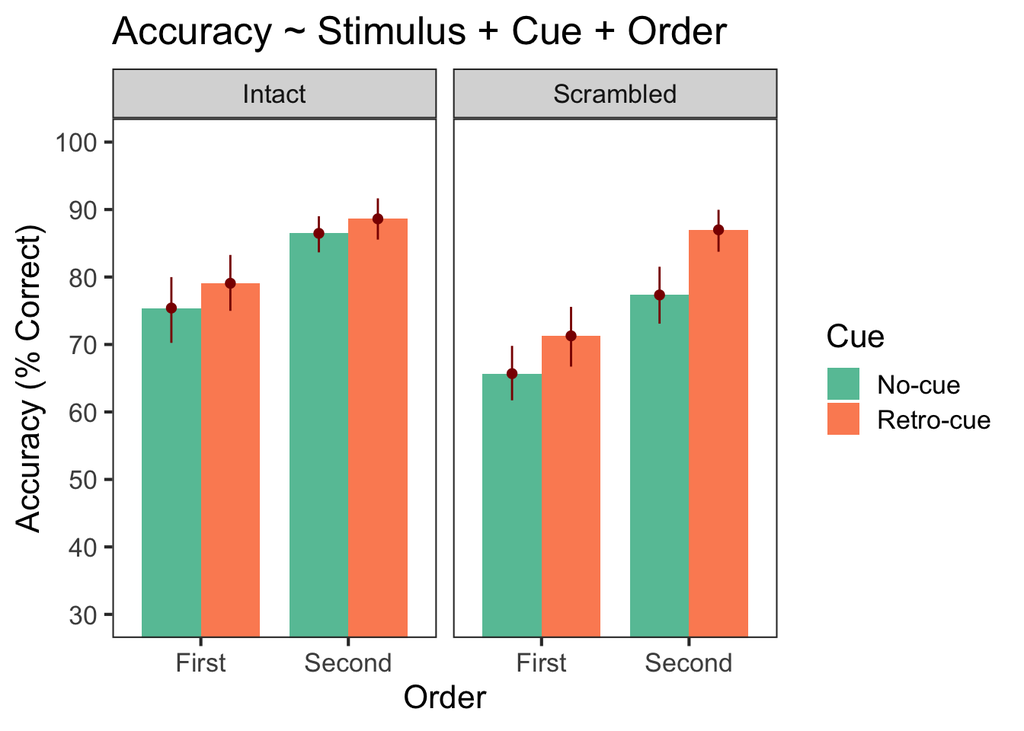

```r
mt.ind2 %>% ggplot(aes(x = Order, Stimulus, y = Accuracy * 100, fill = Cue)) +
  stat_summary(fun = mean,
               geom = "bar",
               position = position_dodge(width = 0.8),
               aes(fill = Cue),
               width = 0.8) +
  stat_summary(fun.data = "mean_cl_boot",
               position = position_dodge(width = 0.8),
               color = "darkred",
               size = 0.3, show.legend = FALSE) +
  facet_wrap(~Stimulus) +
  scale_fill_brewer(labels = c("NoCue" = "No-cue", "RetroCue" = "Retro-cue"),
                    palette = "Set2") +
  labs(x = "Order", y = "Accuracy (% Correct)") +
  coord_cartesian(ylim = c(30, 100), clip = "on") +
  scale_y_continuous(breaks=seq(30, 100, by = 10)) +
  ggtitle('Accuracy ~ Stimulus + Cue + Order') +
  theme_bw(base_size = 16) +
  theme(panel.grid.major = element_blank(),
        panel.grid.minor = element_blank())
```

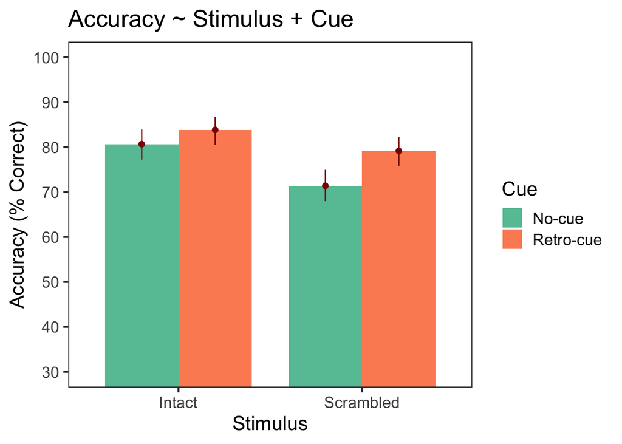

```r
# Accuracy ~ Stimulus + Cue; bar plot
mt.ind22 %>% ggplot(aes(x = Stimulus, y = Accuracy*100, fill = Cue)) +
  stat_summary(fun = mean,
               geom = "bar",
               position = position_dodge(width = 0.8),
               aes(fill = Cue),
               width = 0.8) +
  stat_summary(fun.data = "mean_cl_boot",
               position = position_dodge(width = 0.8),
               color = "darkred",
               size = 0.3, show.legend = FALSE) +
  scale_fill_brewer(labels = c("NoCue" = "No-cue", "RetroCue" = "Retro-cue"),
                    palette = "Set2") +
  labs(x = "Stimulus", y = "Accuracy (% Correct)") +
  coord_cartesian(ylim = c(30, 100), clip = "on") +
  scale_y_continuous(breaks=seq(30, 100, by = 10)) +
  ggtitle('Accuracy ~ Stimulus + Cue') +
  theme_bw(base_size = 16) +
  theme(panel.grid.major = element_blank(),
        panel.grid.minor = element_blank())
```

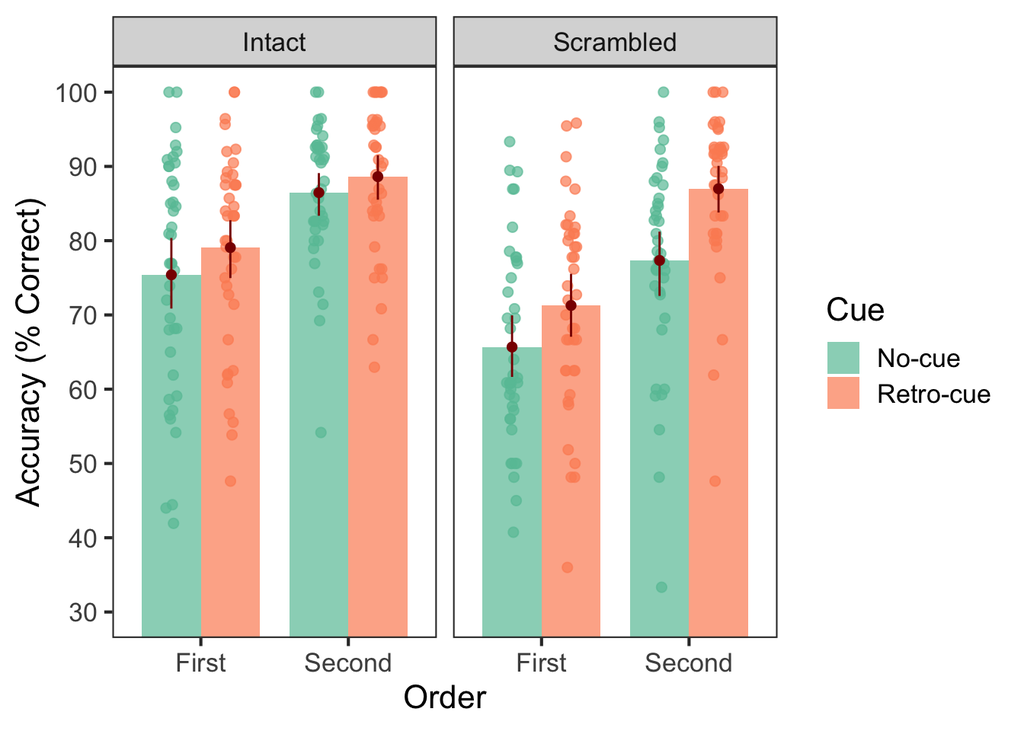

```r
# Accuracy ~ Stimulus + Cue + Order with participants data
mt.ind2 %>%
  ggplot(aes(x = Order, y = Accuracy*100, fill = Cue)) +
  stat_summary(fun = mean,
               geom = "bar",
               position = position_dodge(width = 0.8),
               aes(fill = Cue),
               width = 0.8, alpha = 0.7) +
  geom_point(aes(color = Cue),
             position = position_jitterdodge(jitter.width = 0.15, dodge.width = 0.8),
             size = 2, alpha = 0.7,
             show.legend = FALSE) +
  stat_summary(fun.data = "mean_cl_boot",
               position = position_dodge(width = 0.8),
               color = "darkred",
               size = 0.3, show.legend = FALSE) +
  scale_fill_brewer(labels = c("NoCue" = "No-cue", "RetroCue" = "Retro-cue"),
                    palette = "Set2") +
  scale_color_brewer(palette = "Set2") +
  labs(x = "Order", y = "Accuracy (% Correct)") +
  coord_cartesian(ylim = c(30, 100), clip = "on") +
  scale_y_continuous(breaks=seq(30, 100, by = 10)) +
  facet_wrap(~Stimulus) +
  theme_bw(base_size = 16) +
  theme(panel.grid.major = element_blank(),
        panel.grid.minor = element_blank())
```

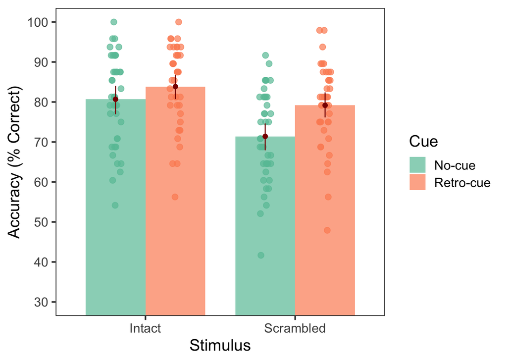

```r
# Accuracy ~ Stimulus + Cue with participants data
mt.ind22 %>%
  ggplot(aes(x = Stimulus, y = Accuracy*100, fill = Cue)) +
  stat_summary(fun = mean,
               geom = "bar",
               position = position_dodge(width = 0.8),
               aes(fill = Cue),
               width = 0.8, alpha = 0.7) +
  geom_point(aes(color = Cue),
             position = position_jitterdodge(jitter.width = 0.15, dodge.width = 0.8),
             size = 2.5, alpha = 0.7,
             show.legend = FALSE) +
  stat_summary(fun.data = "mean_cl_boot",
               position = position_dodge(width = 0.8),
               color = "darkred",
               size = 0.3, show.legend = FALSE) +
  scale_fill_brewer(labels = c("NoCue" = "No-cue", "RetroCue" = "Retro-cue"),
                    palette = "Set2") +
  scale_color_brewer(palette = "Set2") +
  labs(x = "Stimulus", y = "Accuracy (% Correct)") +
  coord_cartesian(ylim = c(30, 100), clip = "on") +
  scale_y_continuous(breaks=seq(30, 100, by = 10)) +
  theme_bw(base_size = 16) +
  theme(panel.grid.major = element_blank(),
        panel.grid.minor = element_blank())
```

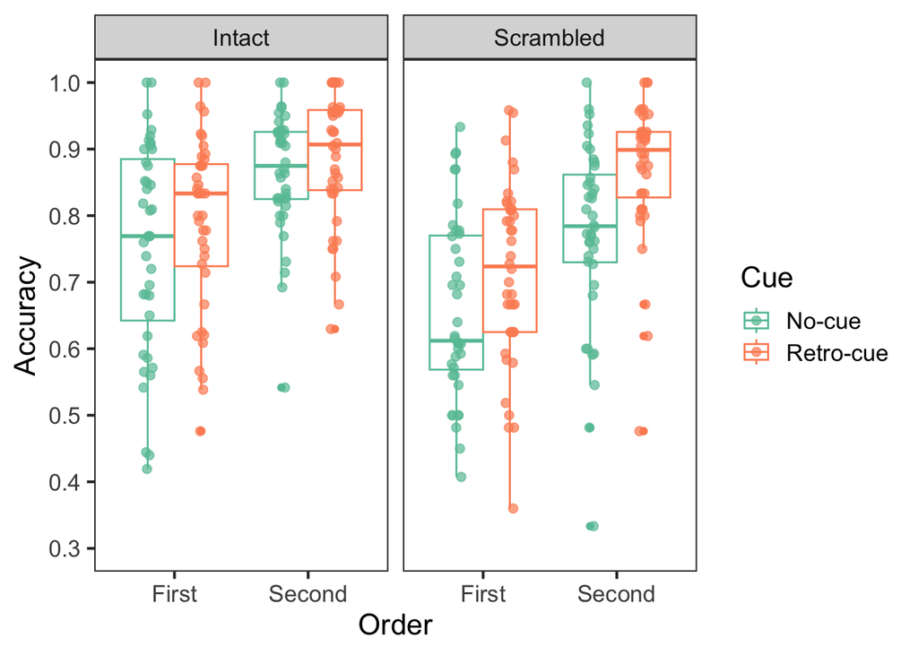

```r
# box plot
mt.ind2 %>%
  ggplot(aes(x = Order, y = Accuracy, color = Cue)) +
  geom_boxplot(position = position_dodge(width = 0.8),
               width = 0.8) +
  geom_point(aes(color = Cue),
             position = position_jitterdodge(jitter.width = 0.15, dodge.width = 0.8),
             alpha = 0.7, size = 2) +
  scale_color_brewer(palette = "Set2",
                     labels = c("NoCue" = "No-cue", "RetroCue" = "Retro-cue")) +
  labs(x = "Order", y = "Accuracy") +
  coord_cartesian(ylim = c(0.3, 1), clip = "on") +
  scale_y_continuous(breaks=seq(0.3, 1, by = 0.1)) +
  facet_wrap(~Stimulus) +
  theme_bw(base_size = 16) +
  theme(panel.grid.major = element_blank(),
        panel.grid.minor = element_blank())
```

### 3.4.3 Anova

```r
anova_test(
  data = mt.ind2, dv = Accuracy, wid = SN,
  within = c(Stimulus, Cue, Order),
  effect.size = "pes")  %>%
  get_anova_table() %>%
  kable(digits = 3, format = "simple", caption = "ANOVA")
```

ANOVA

| Effect | DFn | DFd | F | p | p<.05 | pes |
| --- | --- | --- | --- | --- | --- | --- |
| Stimulus | 1 | 39 | 40.886 | 0.000 | * | 0.512 |
| Cue | 1 | 39 | 25.516 | 0.000 | * | 0.396 |
| Order | 1 | 39 | 93.055 | 0.000 | * | 0.705 |
| Stimulus:Cue | 1 | 39 | 5.823 | 0.021 | * | 0.130 |
| Stimulus:Order | 1 | 39 | 2.272 | 0.140 |  | 0.055 |
| Cue:Order | 1 | 39 | 0.413 | 0.524 |  | 0.010 |
| Stimulus:Cue:Order | 1 | 39 | 2.250 | 0.142 |  | 0.055 |

```r
model <- aov(Accuracy ~ Stimulus * Cue * Order + Error(SN/(Stimulus * Cue * Order)), data = mt.ind2)

emmeans(model, ~ Stimulus*Cue) %>%
  pairs(adjust = "bonferroni") %>%
  as.data.frame() %>%
  kable(digits = 3, format = "simple", caption = "Post-hoc Analysis for Stimulus * Cue Interaction")
## Note: re-fitting model with sum-to-zero contrasts
## NOTE: Results may be misleading due to involvement in interactions
```

Post-hoc Analysis for Stimulus * Cue Interaction

| contrast | estimate | SE | df | t.ratio | p.value |
| --- | --- | --- | --- | --- | --- |
| Intact NoCue - Scrambled NoCue | 0.094 | 0.015 | 76.833 | 6.390 | 0.000 |
| Intact NoCue - Intact RetroCue | -0.029 | 0.014 | 77.669 | -2.037 | 0.270 |
| Intact NoCue - Scrambled RetroCue | 0.018 | 0.015 | 77.735 | 1.186 | 1.000 |
| Scrambled NoCue - Intact RetroCue | -0.123 | 0.015 | 77.735 | -8.118 | 0.000 |
| Scrambled NoCue - Scrambled RetroCue | -0.076 | 0.014 | 77.669 | -5.336 | 0.000 |
| Intact RetroCue - Scrambled RetroCue | 0.047 | 0.015 | 76.833 | 3.194 | 0.012 |

### 3.4.4 BayesFactor

```r
bf <- anovaBF(Accuracy ~ Stimulus*Cue + SN, data = as.data.frame(mt.ind2),
              whichRandom = "SN", progress = FALSE)
# anovaBF 실행 시 matrix~ 오류 생기면, 아래 코드를 돌린다.
# https://stackoverflow.com/questions/77530214/error-dsparsemodelmatrix-object-superclass-xmatrix-not-defined/77530730#77530730
# install.packages("MatrixModels", type = "source")

bf
```

```
## Bayes factor analysis
## --------------
## [1] Stimulus + SN                      : 61073.42 ±1.34%
## [2] Cue + SN                           : 148.1437 ±1.06%
## [3] Stimulus + Cue + SN                : 19116861 ±2.41%
## [4] Stimulus + Cue + Stimulus:Cue + SN : 14650599 ±2.43%
##
## Against denominator:
##   Accuracy ~ SN
## ---
## Bayes factor type: BFlinearModel, JZS
```

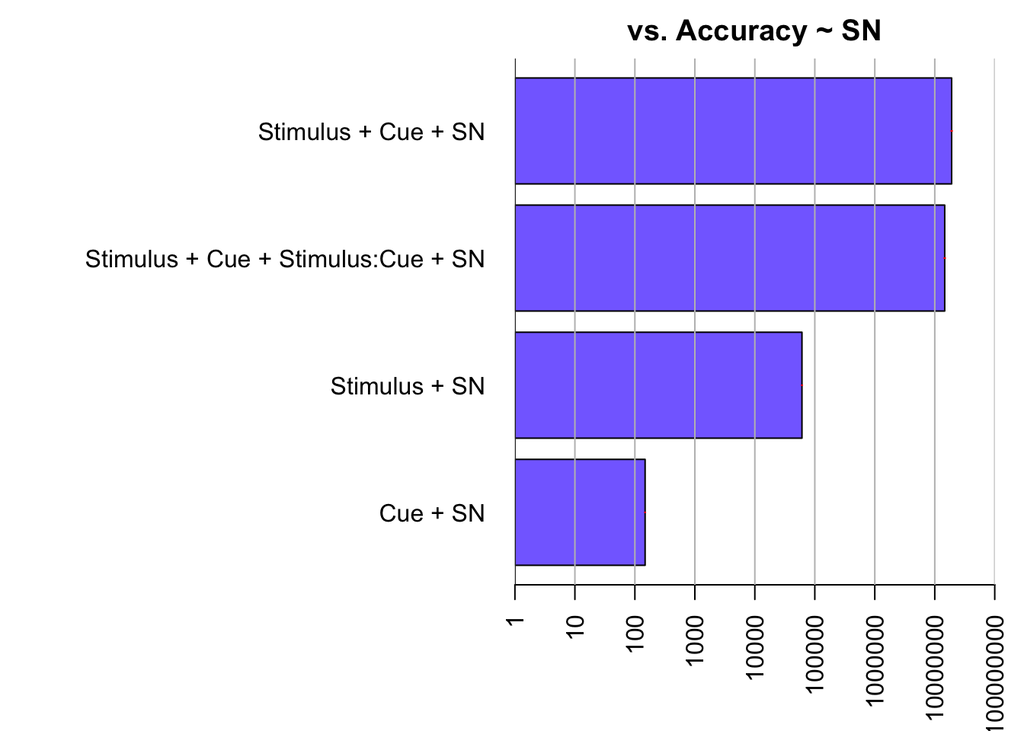

```r
plot(bf)
```

```r
bf[3]/bf[4]
```

```
## Bayes factor analysis
## --------------
## [1] Stimulus + Cue + SN : 1.304852 ±3.42%
##
## Against denominator:
##   Accuracy ~ Stimulus + Cue + Stimulus:Cue + SN
## ---
## Bayes factor type: BFlinearModel, JZS
```

# 4 Exploratory

## 4.1 N = 17

Post-query에서 지시를 따라 과제를 수행했다고 **응답하지 않은** 피험자들만 포함.

```r
mt2 %>%
  filter(Strategy != 1) %>%
  summarise(SN = n_distinct(Subject)) # 17명
## # A tibble: 1 × 1
##      SN
##   <int>
## 1    17

mt.ind3 <- mt2 %>%
  filter(Strategy != 1) %>%
  group_by(SN, Stimulus, Cue, Order) %>%
  summarise(Accuracy = mean(Correct)) %>%
  ungroup()

mt.ind33 <- mt2 %>%
  filter(Strategy != 1) %>%
  group_by(SN, Stimulus, Cue) %>%
  summarise(Accuracy = mean(Correct)) %>%
  ungroup() # 그래프를 위한 것
```

### 4.1.1 Descriptive Stats

```r
mt.ind3 %>%
  group_by(Stimulus, Cue) %>%
  get_summary_stats(Accuracy, type = "common") %>%
  kable(digits = 3, format = "simple", caption = "Descriptive Stats without Order(N=17)")
```

Descriptive Stats without Order(N=17)

| Stimulus | Cue | variable | n | min | max | median | iqr | mean | sd | se | ci |
| --- | --- | --- | --- | --- | --- | --- | --- | --- | --- | --- | --- |
| Intact | NoCue | Accuracy | 34 | 0.519 | 1 | 0.761 | 0.153 | 0.777 | 0.128 | 0.022 | 0.045 |
| Intact | RetroCue | Accuracy | 34 | 0.556 | 1 | 0.854 | 0.154 | 0.836 | 0.117 | 0.020 | 0.041 |
| Scrambled | NoCue | Accuracy | 34 | 0.429 | 1 | 0.737 | 0.221 | 0.730 | 0.149 | 0.025 | 0.052 |
| Scrambled | RetroCue | Accuracy | 34 | 0.500 | 1 | 0.811 | 0.217 | 0.782 | 0.153 | 0.026 | 0.053 |

```r
mt.ind3 %>%
  group_by(SN, Stimulus, Cue) %>%
  summarise(Accuracy = mean(Accuracy)) %>%
  unite(col = 'Condition', Stimulus:Cue) %>%
  pivot_wider(id_cols = c(SN),
              names_from = Condition, values_from = Accuracy) %>%
  mutate(Intact = Intact_RetroCue - Intact_NoCue, # 화살표 단서 활용 효과
         Scrambled = Scrambled_RetroCue - Scrambled_NoCue) %>%
  select(SN, Intact, Scrambled) %>%
  pivot_longer(cols = c(Intact, Scrambled),
               names_to = 'Stimulus',
               values_to = 'CueBenefit') %>%
  group_by(Stimulus) %>%
  get_summary_stats(CueBenefit, type = "common") %>%
  kable(digits = 3, format = "simple", caption = "CueBenefit(N=17)")
```

CueBenefit(N=17)

| Stimulus | variable | n | min | max | median | iqr | mean | sd | se | ci |
| --- | --- | --- | --- | --- | --- | --- | --- | --- | --- | --- |
| Intact | CueBenefit | 17 | -0.062 | 0.169 | 0.059 | 0.064 | 0.059 | 0.063 | 0.015 | 0.033 |
| Scrambled | CueBenefit | 17 | -0.106 | 0.229 | 0.043 | 0.118 | 0.051 | 0.093 | 0.023 | 0.048 |

```r
mt.ind3 %>%
  group_by(Stimulus, Cue, Order) %>%
  get_summary_stats(Accuracy, type = "common") %>%
  kable(digits = 3, format = "simple", caption = "Descriptive Stats with Order")
```

Descriptive Stats with Order

| Stimulus | Cue | Order | variable | n | min | max | median | iqr | mean | sd | se | ci |
| --- | --- | --- | --- | --- | --- | --- | --- | --- | --- | --- | --- | --- |
| Intact | NoCue | First | Accuracy | 17 | 0.519 | 0.938 | 0.714 | 0.109 | 0.697 | 0.106 | 0.026 | 0.054 |
| Intact | NoCue | Second | Accuracy | 17 | 0.704 | 1.000 | 0.852 | 0.170 | 0.858 | 0.095 | 0.023 | 0.049 |
| Intact | RetroCue | First | Accuracy | 17 | 0.556 | 0.923 | 0.783 | 0.130 | 0.773 | 0.111 | 0.027 | 0.057 |
| Intact | RetroCue | Second | Accuracy | 17 | 0.727 | 1.000 | 0.905 | 0.103 | 0.900 | 0.085 | 0.021 | 0.044 |
| Scrambled | NoCue | First | Accuracy | 17 | 0.429 | 0.850 | 0.630 | 0.117 | 0.644 | 0.113 | 0.027 | 0.058 |
| Scrambled | NoCue | Second | Accuracy | 17 | 0.526 | 1.000 | 0.815 | 0.151 | 0.816 | 0.131 | 0.032 | 0.067 |
| Scrambled | RetroCue | First | Accuracy | 17 | 0.500 | 0.917 | 0.708 | 0.314 | 0.709 | 0.149 | 0.036 | 0.077 |
| Scrambled | RetroCue | Second | Accuracy | 17 | 0.619 | 1.000 | 0.870 | 0.151 | 0.855 | 0.121 | 0.029 | 0.062 |

### 4.1.2 Graph

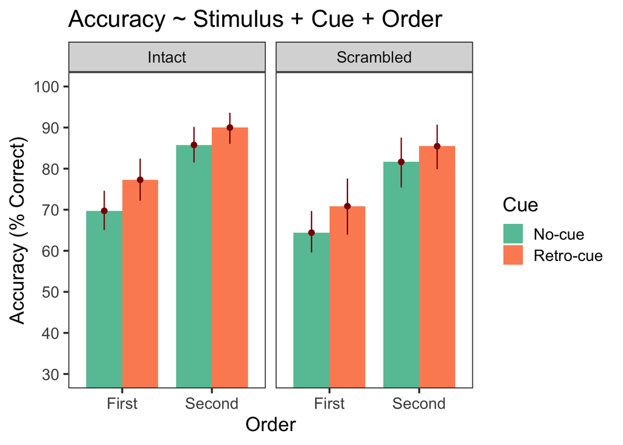

```r
mt.ind3 %>% ggplot(aes(x = Order, Stimulus, y = Accuracy * 100, fill = Cue)) +
  stat_summary(fun = mean,
               geom = "bar",
               position = position_dodge(width = 0.8),
               aes(fill = Cue),
               width = 0.8) +
  stat_summary(fun.data = "mean_cl_boot",
               position = position_dodge(width = 0.8),
               color = "darkred",
               size = 0.3, show.legend = FALSE) +
  facet_wrap(~Stimulus) +
  scale_fill_brewer(labels = c("NoCue" = "No-cue", "RetroCue" = "Retro-cue"),
                    palette = "Set2") +
  labs(x = "Order", y = "Accuracy (% Correct)") +
  coord_cartesian(ylim = c(30, 100), clip = "on") +
  scale_y_continuous(breaks=seq(30, 100, by = 10)) +
  ggtitle('Accuracy ~ Stimulus + Cue + Order') +
  theme_bw(base_size = 16) +
  theme(panel.grid.major = element_blank(),
        panel.grid.minor = element_blank())
```

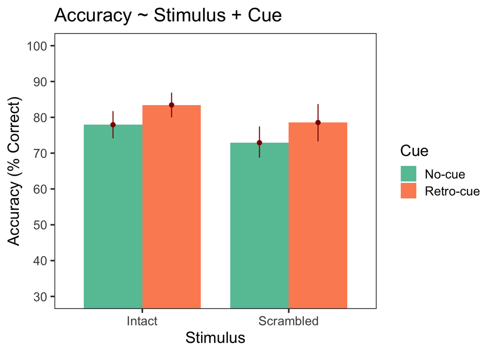

```r
# Accuracy ~ Stimulus + Cue; bar plot
mt.ind33 %>% ggplot(aes(x = Stimulus, y = Accuracy*100, fill = Cue)) +
  stat_summary(fun = mean,
               geom = "bar",
               position = position_dodge(width = 0.8),
               aes(fill = Cue),
               width = 0.8) +
  stat_summary(fun.data = "mean_cl_boot",
               position = position_dodge(width = 0.8),
               color = "darkred",
               size = 0.3, show.legend = FALSE) +
  scale_fill_brewer(labels = c("NoCue" = "No-cue", "RetroCue" = "Retro-cue"),
                    palette = "Set2") +
  labs(x = "Stimulus", y = "Accuracy (% Correct)") +
  coord_cartesian(ylim = c(30, 100), clip = "on") +
  scale_y_continuous(breaks=seq(30, 100, by = 10)) +
  ggtitle('Accuracy ~ Stimulus + Cue') +
  theme_bw(base_size = 16) +
  theme(panel.grid.major = element_blank(),
        panel.grid.minor = element_blank())
```

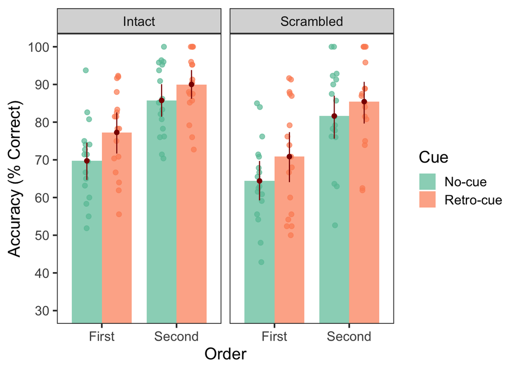

```r
# Accuracy ~ Stimulus + Cue + Order with participants data
mt.ind3 %>%
  ggplot(aes(x = Order, y = Accuracy*100, fill = Cue)) +
  stat_summary(fun = mean,
               geom = "bar",
               position = position_dodge(width = 0.8),
               aes(fill = Cue),
               width = 0.8, alpha = 0.7) +
  geom_point(aes(color = Cue),
             position = position_jitterdodge(jitter.width = 0.15, dodge.width = 0.8),
             size = 2, alpha = 0.7,
             show.legend = FALSE) +
  stat_summary(fun.data = "mean_cl_boot",
               position = position_dodge(width = 0.8),
               color = "darkred",
               size = 0.3, show.legend = FALSE) +
  scale_fill_brewer(labels = c("NoCue" = "No-cue", "RetroCue" = "Retro-cue"),
                    palette = "Set2") +
  scale_color_brewer(palette = "Set2") +
  labs(x = "Order", y = "Accuracy (% Correct)") +
  coord_cartesian(ylim = c(30, 100), clip = "on") +
  scale_y_continuous(breaks=seq(30, 100, by = 10)) +
  facet_wrap(~Stimulus) +
  theme_bw(base_size = 16) +
  theme(panel.grid.major = element_blank(),
        panel.grid.minor = element_blank())
```

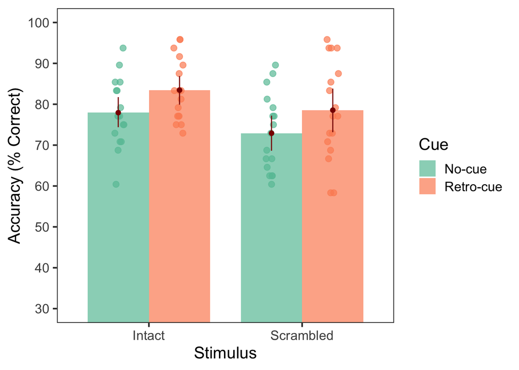

```r
# Accuracy ~ Stimulus + Cue with participants data
mt.ind33 %>%
  ggplot(aes(x = Stimulus, y = Accuracy*100, fill = Cue)) +
  stat_summary(fun = mean,
               geom = "bar",
               position = position_dodge(width = 0.8),
               aes(fill = Cue),
               width = 0.8, alpha = 0.7) +
  geom_point(aes(color = Cue),
             position = position_jitterdodge(jitter.width = 0.15, dodge.width = 0.8),
             size = 2.5, alpha = 0.7,
             show.legend = FALSE) +
  stat_summary(fun.data = "mean_cl_boot",
               position = position_dodge(width = 0.8),
               color = "darkred",
               size = 0.3, show.legend = FALSE) +
  scale_fill_brewer(labels = c("NoCue" = "No-cue", "RetroCue" = "Retro-cue"),
                    palette = "Set2") +
  scale_color_brewer(palette = "Set2") +
  labs(x = "Stimulus", y = "Accuracy (% Correct)") +
  coord_cartesian(ylim = c(30, 100), clip = "on") +
  scale_y_continuous(breaks=seq(30, 100, by = 10)) +
  theme_bw(base_size = 16) +
  theme(panel.grid.major = element_blank(),
        panel.grid.minor = element_blank())
```

### 4.1.3 Anova

```r
anova_test(
  data = mt.ind3, dv = Accuracy, wid = SN,
  within = c(Stimulus, Cue, Order),
  effect.size = "pes")  %>%
  get_anova_table() %>%
  kable(digits = 3, format = "simple", caption = "ANOVA")
```

ANOVA

| Effect | DFn | DFd | F | p | p<.05 | pes |
| --- | --- | --- | --- | --- | --- | --- |
| Stimulus | 1 | 16 | 9.756 | 0.007 | * | 0.379 |
| Cue | 1 | 16 | 21.704 | 0.000 | * | 0.576 |
| Order | 1 | 16 | 71.784 | 0.000 | * | 0.818 |
| Stimulus:Cue | 1 | 16 | 0.061 | 0.808 |  | 0.004 |
| Stimulus:Order | 1 | 16 | 0.235 | 0.634 |  | 0.014 |
| Cue:Order | 1 | 16 | 0.983 | 0.336 |  | 0.058 |
| Stimulus:Cue:Order | 1 | 16 | 0.014 | 0.907 |  | 0.001 |

## 4.2 N = 40 vs. N = 17

```r
mt3 <- mt2 %>%
  mutate(usingCue = ifelse(Strategy == 1, 1, 0)) %>%
  group_by(SN, Stimulus, Cue, usingCue) %>%
  summarise(Accuracy = mean(Correct)) %>%
  ungroup()

anova_test(
  data = mt3, dv = Accuracy, wid = SN,
  between = usingCue,
  within = c(Stimulus, Cue),
  effect.size = "pes")  %>%
  get_anova_table() %>%
  kable(digits = 3, format = "simple", caption = "ANOVA")
```

ANOVA

| Effect | DFn | DFd | F | p | p<.05 | pes |
| --- | --- | --- | --- | --- | --- | --- |
| usingCue | 1 | 55 | 0.049 | 0.826 |  | 0.001 |
| Stimulus | 1 | 55 | 31.390 | 0.000 | * | 0.363 |
| Cue | 1 | 55 | 38.512 | 0.000 | * | 0.412 |
| usingCue:Stimulus | 1 | 55 | 0.894 | 0.348 |  | 0.016 |
| usingCue:Cue | 1 | 55 | 0.004 | 0.952 |  | 0.000 |
| Stimulus:Cue | 1 | 55 | 1.595 | 0.212 |  | 0.028 |
| usingCue:Stimulus:Cue | 1 | 55 | 1.433 | 0.236 |  | 0.025 |

## 4.3 Target과 Response의 거리에 따라

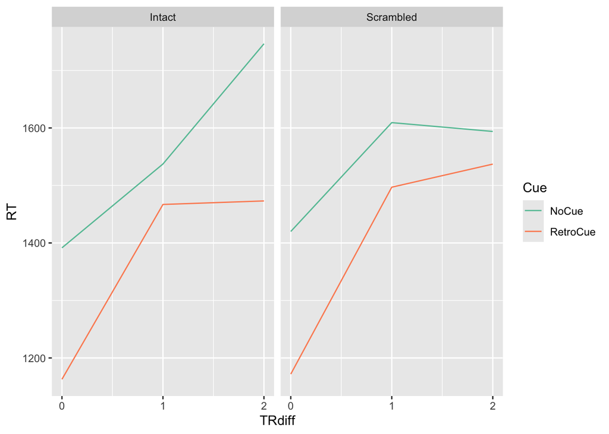

```r
mt4 <- mt2 %>%
  mutate(TRdiff = abs(Key - as.numeric(Response)))

# RT
mt4 %>%
  ggplot(aes(x = TRdiff, y = RT, color = Cue)) +
  stat_summary(fun = mean, geom = "line") +
  scale_color_brewer(palette = "Set2") +
  scale_x_continuous(breaks = c(0, 1, 2)) +
  facet_wrap(~Stimulus)
```

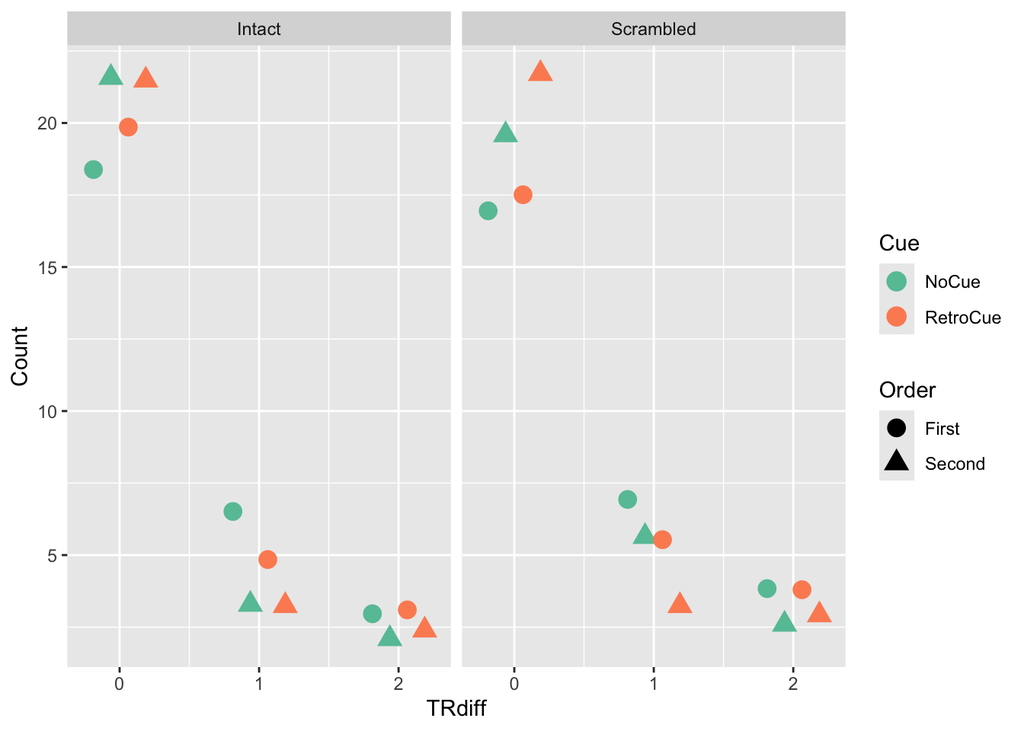

```r
# Correct
mt.ind4 <- mt4 %>%
  group_by(SN, Stimulus, Cue, Order, TRdiff) %>%
  mutate(c.TRdiff = n())

mt.ind4 %>%
  ggplot(aes(x = TRdiff, y = c.TRdiff, color = Cue, shape = Order)) +
  stat_summary(fun = mean, geom = "point",
               position = position_jitterdodge(jitter.width = 0, dodge.width = 0.5), size = 4) +
  scale_color_brewer(palette = "Set2") +
  scale_x_continuous(breaks = c(0, 1, 2)) +
  facet_wrap(~Stimulus) +
  labs(y = "Count")
```

## 4.4 수행률에 따라

정확도를 median기준으로 나눠 보아도 패턴은 똑같이 나온다.

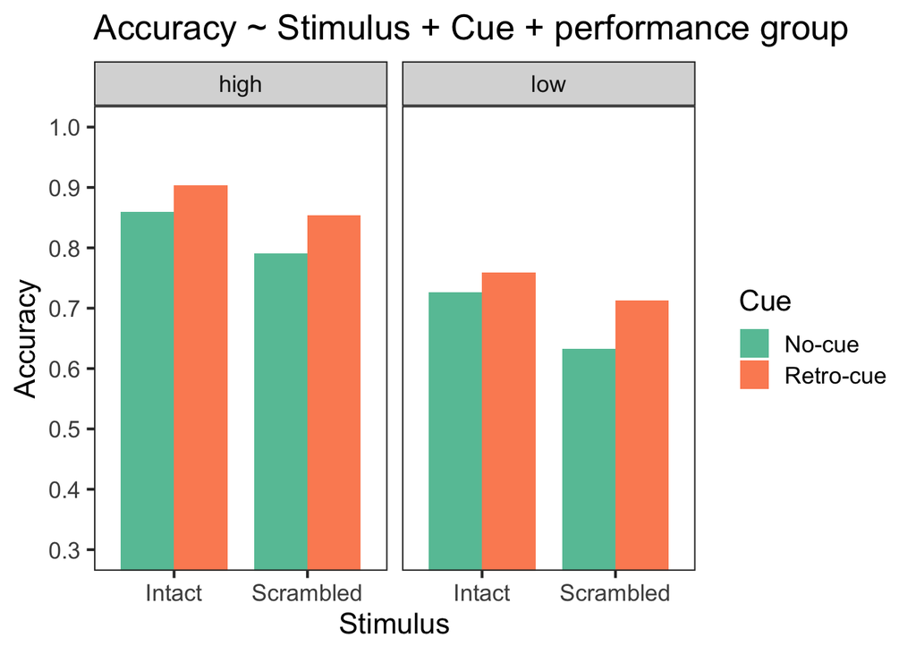

```r
mt.gacc <- mt.gacc %>%
  mutate(Perf = ifelse(M >= median(M), 'high', 'low'))

mt5 <- full_join( mt2 %>% group_by(Subject) %>% nest(),
                  mt.gacc %>% select(Subject, Perf),
                  by = join_by(Subject)) %>%
  unnest(data) %>%
  ungroup()

mt.ind5 <- mt5 %>%
  group_by(SN, Stimulus, Cue, Perf) %>%
  summarise(Accuracy = mean(Correct)) %>%
  ungroup()

mt.ind5 %>% ggplot(aes(x = Stimulus, Perf, y = Accuracy, fill = Cue)) +
  stat_summary(fun = mean,
               geom = "bar",
               position = position_dodge(width = 0.8),
               width = 0.8) +
  facet_wrap(~Perf) +
  coord_cartesian(ylim = c(0.3, 1), clip = "on") +
  scale_y_continuous(breaks=seq(0.3, 1, by = 0.1)) +
  scale_fill_brewer(labels = c("NoCue" = "No-cue", "RetroCue" = "Retro-cue"),
                    palette = "Set2") +
  labs(x = "Stimulus", y = "Accuracy") +
  ggtitle('Accuracy ~ Stimulus + Cue + performance group') +
  theme_bw(base_size = 16) +
  theme(panel.grid.major = element_blank(),
        panel.grid.minor = element_blank())
```

## 4.5 반응시간 제한

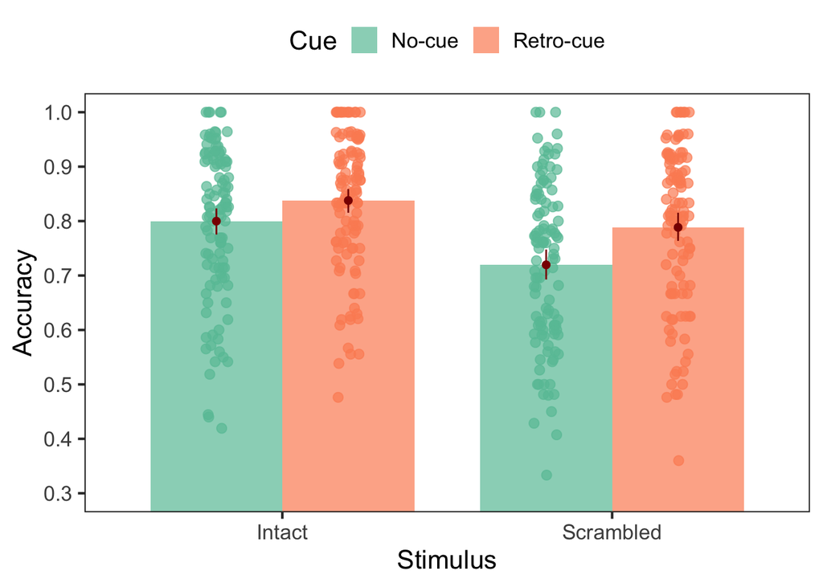

```r
mt6 <- mt2 %>%
  mutate(Correct = ifelse(RT > 10000, 0, Correct))

mt.ind6 <- mt6 %>%
  group_by(SN, Stimulus, Cue, Order) %>%
  summarise(Accuracy = mean(Correct)) %>%
  ungroup()

mt.ind6 %>%
  ggplot(aes(x = Stimulus, y = Accuracy, fill = Cue)) +
  stat_summary(fun = mean,
               geom = "bar",
               position = position_dodge(width = 0.8),
               aes(fill = Cue),
               width = 0.8, alpha = 0.7) +
  geom_point(aes(color = Cue),
             position = position_jitterdodge(jitter.width = 0.15, dodge.width = 0.8),
             size = 2.5, alpha = 0.7,
             show.legend = FALSE) +
  stat_summary(fun.data = "mean_cl_boot",
               position = position_dodge(width = 0.8),
               color = "darkred",
               size = 0.3, show.legend = FALSE) +
  scale_fill_brewer(labels = c("NoCue" = "No-cue", "RetroCue" = "Retro-cue"),
                    palette = "Set2") +
  scale_color_brewer(palette = "Set2") +
  labs(x = "Stimulus", y = "Accuracy") +
  coord_cartesian(ylim = c(0.3, 1), clip = "on") +
  scale_y_continuous(breaks=seq(0.3, 1, by = 0.1)) +
  theme_bw(base_size = 16) +
  theme(legend.position = "top",
        panel.grid.major = element_blank(),
        panel.grid.minor = element_blank())
```

## 4.6 N-1 시행 고려

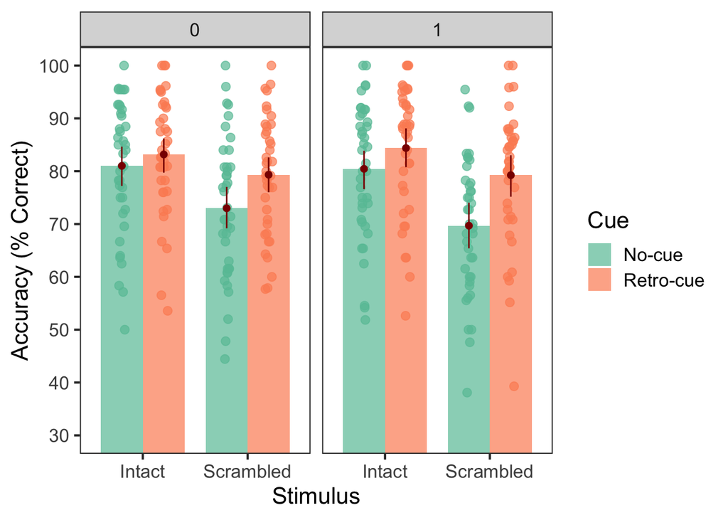

```r
mt7 <- mt2 %>%
  group_by(SN) %>%
  arrange(Trials, .by_group = TRUE) %>%
  mutate(N1 = lag(Stimulus) == "Intact",
         N1 = if_else(is.na(N1), 0, as.numeric(N1))) %>%
  ungroup()

mt.ind7 <- mt7 %>%
  filter(Strategy == 1) %>%
  group_by(SN, Stimulus, Cue, N1) %>%
  summarise(Accuracy = mean(Correct)) %>%
  ungroup()

mt.ind7 %>%
  ggplot(aes(x = Stimulus, y = Accuracy*100, fill = Cue)) +
  stat_summary(fun = mean,
               geom = "bar",
               position = position_dodge(width = 0.8),
               aes(fill = Cue),
               width = 0.8, alpha = 0.7) +
  geom_point(aes(color = Cue),
             position = position_jitterdodge(jitter.width = 0.15, dodge.width = 0.8),
             size = 2.5, alpha = 0.7,
             show.legend = FALSE) +
  stat_summary(fun.data = "mean_cl_boot",
               position = position_dodge(width = 0.8),
               color = "darkred",
               size = 0.3, show.legend = FALSE) +
  scale_fill_brewer(labels = c("NoCue" = "No-cue", "RetroCue" = "Retro-cue"),
                    palette = "Set2") +
  scale_color_brewer(palette = "Set2") +
  labs(x = "Stimulus", y = "Accuracy (% Correct)") +
  coord_cartesian(ylim = c(30, 100), clip = "on") +
  scale_y_continuous(breaks=seq(30, 100, by = 10)) +
  facet_wrap(~N1) +
  theme_bw(base_size = 16) +
  theme(panel.grid.major = element_blank(),
        panel.grid.minor = element_blank())
```